# ENAHO con R

Josue Benites

28/9/2021

La documentación presentada a continuación tiene como finalidad ayudar en familiarización en la construcción y estimación de indicadores económicos de la Encuesta Nacional de Hogares del INEI (Perú) usando R. Por ello les mostraré en la primera sección del archivo la manipulación de datos de la ENAHO, así como la visualización de los indicadores vinculados a informalidad y estructura según condición de formalidad del empleo(formal - informal). La segunda sección está destinada a la utilización de los factores de expansión. Para el módulo 500 de la ENAHO, la estimación se centra en la variable *fac500a*. En la última sección podrán encontrar el código correspondiente para realizar un mapa del Perú a nivel departamental con los datos calculados en las otras secciones.

# Manipulación de los datos y visualización

## Parquetes a utilizar

El principal paquete a utilizar para la manipulación de los datos es “dplyr”. Sus funciones **mutate**, **select** y **filter** nos son de utilidad para modelar de manera amigable.

```r
library(haven) #Lectura de archivos en formato dta
library(dplyr) #Manipulación de la data
```

```r
library(ggplot2) #Visualización de los datos
```

## Bases de datos

Cargamos la base de los archivos dta con la función **read_dta**. Nos apoyamos en un loop para leer las bases de los año 2019 a 2020.

```r
for(i in 2019:2020) {
  #Asignamos nombre de archivo y lo que leerá
  assign(paste0("data_", i),
         #Leer el archivo dta
         read_dta(paste0("enaho01a-",i,"-500.dta")))
}
```

Con la función **bind_rows** realizamos la fusión de los datos para consolidarlo en una sola base de datos. Para quienes usan STATA, esa función sería similar a realizar un apppend. Con **select** nos quedamos con las variables de interés como el año hasta lo que sería el estrato. Debemos mencionar que construiremos con las variables p204, p205 y p206 la variable que indique los residentes del hogar.

```r
data<-bind_rows(data_2019, data_2020)%>%
  select(aÑo : codinfor, p204 : p206, ocu500, ocupinf, fac500a)
head(data)
```

```
## # A tibble: 6 x 17
##   aÑo   mes   nconglome conglome vivienda hogar codperso ubigeo  dominio estrato
##   <chr> <chr> <chr>     <chr>    <chr>    <chr> <chr>    <chr>  <dbl+lb> <dbl+l>
## 1 2019  01    007076    005009   041      11    01       010101 4 [sier~ 4 [ de~
## 2 2019  01    007076    005009   041      11    02       010101 4 [sier~ 4 [ de~
## 3 2019  01    007076    005009   056      11    01       010101 4 [sier~ 4 [ de~
## 4 2019  01    007076    005009   056      11    02       010101 4 [sier~ 4 [ de~
## 5 2019  01    007076    005009   056      11    03       010101 4 [sier~ 4 [ de~
## 6 2019  01    007076    005009   084      11    01       010101 4 [sier~ 4 [ de~
## # ... with 7 more variables: codinfor <chr>, p204 <dbl+lbl>, p205 <dbl+lbl>,
## #   p206 <dbl+lbl>, ocu500 <dbl+lbl>, ocupinf <dbl>, fac500a <dbl>
```

Las variables que nos permiten conostruir los datos de informlidad son los siguientes: ocu500 y ocupinf.

### Sobre ocu500

Es el indicador de la PEA (INEI). Nos será útil para construir la dummy de PEA y NO PEA.

```r
#Para ver los labels de la variable [Solo en algunos casos cargan y en otros no]
attributes(data$ocu500)$labels
```

```
##            ocupado desocupado abierto  desocupado oculto             no pea
##                  1                  2                  3                  4
```

### Sobre ocupinf

Es la situación de informalidad (ocup.principal - INEI). Cuando es empleo informal se le asigna 1; cuando es empleo formal, 2.

## Variables geográficas

Creamos variables geográficas como zona, área, zona - área y departamento de las variables dominio, estrato y departamento.

```r
attributes(data$dominio)$labels
```

```
##        costa norte       costa centro          costa sur       sierra norte
##                  1                  2                  3                  4
##      sierra centro         sierra sur              selva lima metropolitana
##                  5                  6                  7                  8
```

```r
attributes(data$estrato)$labels
```

```
##                    de 500 000 a más habitantes
##                                              1
##                de 100 000 a 499 999 habitantes
##                                              2
##                  de 50 000 a 99 999 habitantes
##                                              3
##                  de 20 000 a 49 999 habitantes
##                                              4
##                   de 2 000 a 19 999 habitantes
##                                              5
##                      de 500 a 1 999 habitantes
##                                              6
##  Área de empadronamiento rural (aer) compuesto
##                                              7
##     Área de empadronamiento rural (aer) simple
##                                              8
```

```r
data<-data%>%
    mutate(
    #Creamos la variable zona geográfica
    zona=if_else((dominio>=1 & dominio<=3 ),"Costa",
                      if_else((dominio>=4 & dominio<=6 ), "Sierra",
                      if_else((dominio==7 ),"Selva",
                              if_else((dominio==8),"Lima Metropolitana",
                                      #En caso no cumpla con ninguno, NA
                                      NULL)))),
    #Creamos la variable área geográfica
    area=if_else((estrato>=1&estrato<=5),"Urbano",
                 if_else((estrato>=6),"Rural",NULL)),
    #Creamos la zona_INEI
    zona_area=if_else(dominio<8,paste0(zona," ",area),
                      if_else(dominio==8,zona,NULL)),
    #Creamos la variable de ID Departamento
    departamento=substr(ubigeo,1,2))
```

## Variables para la estimación de informalidad

Asignaremos una dummy para quienes sean residentes: 1 si lo es - 0 si es que no. Utilizamos una dummy para quienes son PEA Ocupada y tienen un empleo en el sector informal. A esta última dummy la utilizaremos más adelante para genera la tasa de informalidad (promedio) y como categórica al momento de realizar la descripción del mercado laboral según condición de formalidad.

```r
data<-data%>%
  #Creamos la variable residente
  mutate(residente=if_else((p204==1 & p205==2), 1,
                           if_else((p206==1 & p204==2) , 1,
                                   0)))%>%
  #Nos quedamos con los residentes para la estimación de indicadores
  filter(residente==1)%>%
  #Variables a utilizar para informalidad
  mutate(
    #Creamos variable PEA
    pea=if_else((ocu500>=1 & ocu500<=3),1,NULL),
    #Creamos variable PEA Ocupada
    pea_ocu=if_else((ocu500==1),1,NULL),
    #Creamos la variable informal: 1 si lo es ; 0 si es formal
    informal=if_else(( ocupinf==1 & pea_ocu==1),1,
                          if_else(( ocupinf==2 & pea_ocu==1),0, NULL)))
```

## Tabla de ID por Departamentos

Creamos una **data frame** con los datos de departamenos y sus ID. Se podría realizar la asignación de nombres con if_else anidados, pero por comodidad emparejamos las bases de datos.

```r
regiones<-data.frame(
  # Del 1 al 25
  id= c(01:25),
  # Asignamos los nombres de los departamentos
  departamentos=c("Amazonas", "Ancash", "Apurimac", "Arequipa", "Ayacucho", "Cajamarca", "Callao", "Cusco", "Huancavelica", "Huanuco", "Ica","Junin", "La Libertad","Lambayeque", "Lima", "Loreto", "Madre De Dios", "Moquegua", "Pasco", "Piura", "Puno" , "San Martin", "Tacna" , "Tumbes" , "Ucayali")
  )%>%
  #Generamos los ID departamentales para el posterior emparejamiento
  mutate(id=if_else(id<10,paste0("0",id),paste0(id)))
```

Juntamos nuestra data consolidada con los ID de los departamentos. Comentario: + depapartamento: ID de los departamentos + departamentos: Nombre de los departamenos

```r
data<-left_join(data, regiones,
              by = c("departamento" = "id"))
```

## Cálculo de tasa de informalidad

- El comando **ddply** del paquete “plyr” nos sirve para crear la tabla por grupo.
- El paquete “Hmisc” lo utilizaremos para calcular los estadísticos con los factores de expansión. Para calcular la tasa de informalidad, usaremos el comando **wtd.mean**

```r
library(Hmisc) #Estimación con factor de expansión
library(plyr) #Output como tabla
```

Fórmula:

```r
#ddply(Base de datos ~ Desagregado 1 + ... + Deagregado N, summarise,
          #Promedio ponderador=wtd.mean(variable,factor de expansión,na.rm=T))
```

El **arrange** es para ordenar por Departamento y Año. En este ejemplo realizamos la estimación de la tasa de informalidad por año y departamento con el factor de expansión.

```r
informal<-data%>%
  ddply(
    #Departamento y año como variables de desagregación
    ~aÑo+departamentos,
    summarise,
              Informalidad=100*wtd.mean(informal,fac500a, na.rm=T))%>%
  #Agrupamos los departamentos por año
  arrange(departamentos, aÑo)
#Presentamos la base con los factores de expansión
head(informal)
```

```
##    aÑo departamentos Informalidad
## 1 2019      Amazonas     86.58393
## 2 2020      Amazonas     88.08515
## 3 2019        Ancash     78.69049
## 4 2020        Ancash     81.90483
## 5 2019      Apurimac     85.37216
## 6 2020      Apurimac     88.75437
```

## VIsualización de gráfico de barras

Los resultados anteriores los presentados en un gráfico de barras que nos permita comparar la situación de informalidad de la PEA Ocupada en cada departamento para los dos últimos años.

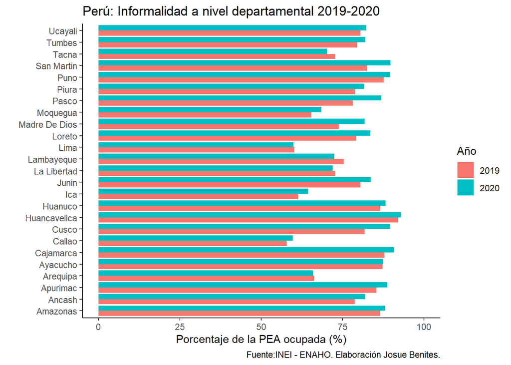

```r
informal%>%
  ggplot(aes(y=departamentos, fill=aÑo, x=Informalidad))+
  #Barras no apiladas
  geom_col(position = "dodge")+
  labs(y="",x="Porcentaje de la PEA ocupada (%)",fill="Año",
       title="Perú: Informalidad a nivel departamental 2019-2020",
       caption = "Fuente:INEI - ENAHO. Elaboración Josue Benites.")+
  xlim(0,100)+
  #Asignamos tema clásico
  theme_classic()
```

```r
ggsave("plot_1.png")
```

Realizamos el cálculo de la tasa de informalidad según Área(rural versus urbano) en un gráfico de barras para el mismo periodo de años.

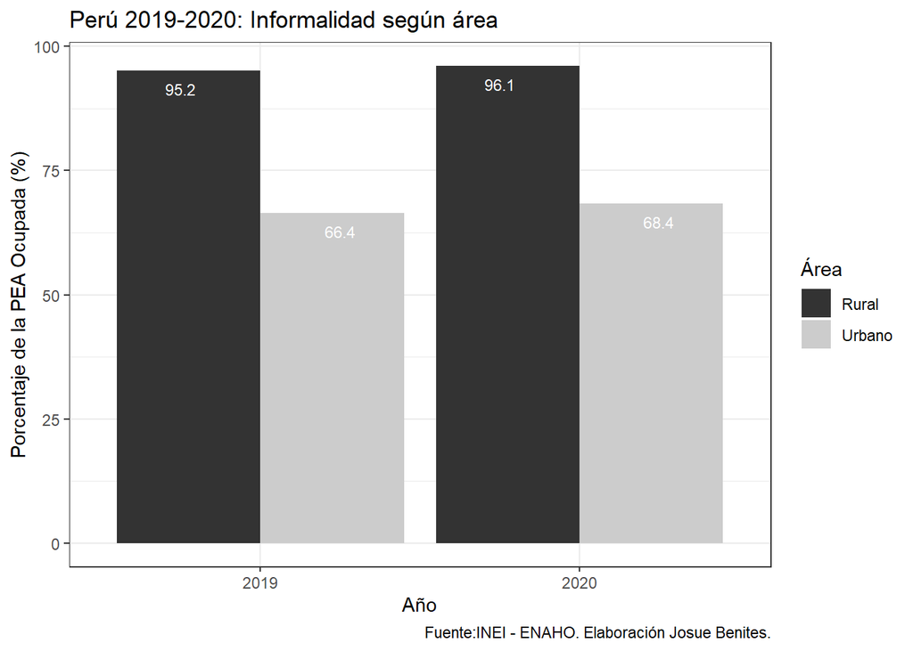

```r
data%>%
  ddply(~aÑo+area,summarise,
              Informalidad=100*wtd.mean(informal,fac500a, na.rm=T))%>%
  ggplot(aes(x=aÑo,
             y=Informalidad,
             fill=area,
             label=round(Informalidad,1)))+
  #position dodge para que no apiladas
  geom_col(position = "dodge")+
  #Añadimos la etiqueta del gráfico
  geom_text(
    aes(label = round(Informalidad,1)),
    colour = "white", size = 3,
    vjust = +02, position = position_dodge(1)
  )+
  labs(x="Año",y="Porcentaje de la PEA Ocupada (%)", fill="Área",
       title="Perú 2019-2020: Informalidad según área",
       caption = "Fuente:INEI - ENAHO. Elaboración Josue Benites.")+
  theme_bw()+
  #Cambiamos de estilo de los colores
  scale_fill_grey()
```

```r
ggsave("plot_2.png")
```

# Estimación con xtabs

Otra función para realizar cálculos con factores de expansión es *xtabs*. Nos permite dar las frecuencias de lo solicitado como en la siguiente manera

```r
xtabs(fac500a~aÑo+informal, data = data)
```

```
##       informal
## aÑo           0        1
##   2019  4670325 12462775
##   2020  3674975 11226806
```

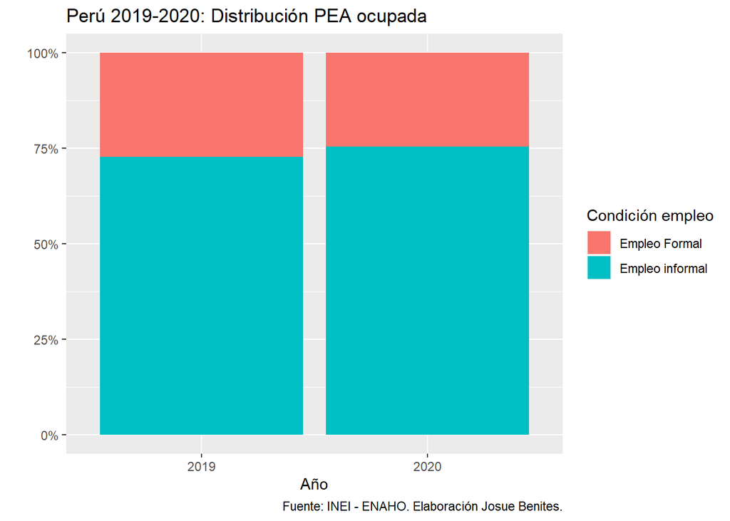

```r
library(ggcharts) # Solo para reescalar a porcentaje
#Convetimos en data frame la estimación
as.data.frame(
  xtabs(fac500a~aÑo+informal, data = data)
  )%>%
  #Ordenamos por AÑo
  arrange(aÑo)%>%
  #"Parte visual"
  ggplot(aes(x=aÑo, y=Freq, fill=as.factor(informal)))+
  # "fill" para que estén encima de manera consolidada
  geom_col(position="fill")+
  #Reescalamos para que se vea porcentaje
  scale_y_continuous(labels = scales::percent)+
  #Etiquetamos 0 como formal y 1 como informal
  scale_fill_discrete(labels=c("Empleo Formal", "Empleo informal"))+
  labs(y="",x="Año", title="Perú 2019-2020: Distribución PEA ocupada",
       fill = "Condición empleo",caption = "Fuente: INEI - ENAHO. Elaboración Josue Benites.")
```

```r
ggsave("plot_3.png")
```

# Mapas

El mapa del Perú con datos de informalidad lo podemos construir con los siguientes paquetes:

```r
library(sf)
library(purrr)
library(ggrepel)
```

## Datos geoespaciales

Cargamos el archivo en formato shape para posteriormente modelar las coordenadas.

```r
#Cargamos los datos shp. del Perú a nivel departamental
peru_sf <- st_read(paste0("E:/PERSONAL/R/Mapas/", "DEPARTAMENTO_27_04_2015.shp"))
#Generamos las coordenadas
peru_sf <- peru_sf %>%
  mutate(centroid = map(geometry, st_centroid),
         coords = map(centroid, st_coordinates),
         coords_x = map_dbl(coords, 1),
         coords_y = map_dbl(coords, 2))
```

## Data a utilizar

Realizamos el filtro para quedarnos solo con el año 2019. Posteriormente realizamos la estimación de la tasa de informalidad para ese año a nivel departamental.

```r
informalidad_2019<-data%>%
  filter(aÑo==2019)%>%
  ddply(~departamento,summarise,
              Informalidad=100*wtd.mean(informal,fac500a, na.rm=T))
#Tasa de informalidad 2019 según departamento
head(informalidad_2019)
```

```
##   departamento Informalidad
## 1           01     86.58393
## 2           02     78.69049
## 3           03     85.37216
## 4           04     66.18030
## 5           05     87.30705
## 6           06     87.88790
```

Realizamos la combinación de la data de **informalidad_2019** con los datos espaciales de la base **peru_sf**.

```r
#Combianamos datos
base_1<-peru_sf %>%
  left_join(informalidad_2019,  by = c("IDDPTO" = "departamento"))
```

## Gráfico del Perú

EL siguiente código nos permite generar un mapa de calor para la informalidad. Apreciamos que a mayor tasa de informalidad, el departamento en cuestión un color más claro.

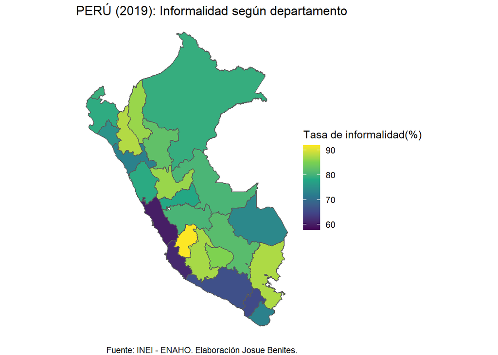

```r
ggplot(base_1) +
  #Utilizamos la informalidad como indicador de color
  geom_sf(aes(fill = Informalidad))+
  labs(title = "PERÚ (2019): Informalidad según departamento",
       caption = "Fuente: INEI - ENAHO. Elaboración Josue Benites.",
       fill = "Tasa de informalidad(%)")+
  #Personalizamos el color de la tasa de informalidad
  scale_fill_viridis_c()+
  theme_void()
```

```r
ggsave("plot_4.png")
```